# Intervention functions in the model

## How does the `rel_beta_change` covariate impact transmission

We are seeing weird dynamics where setting `rel_beta_change = 1` results in different dynamics depending on the value of `log_beta_s`. Recall that `log_beta_s` is $\text{log}(\beta/N)$. To incorporate the affect of social distancing, we include a metric from unacast, here called $\phi$: $\text{log}(\beta/N)\phi(t)$.

We will explore how $\phi(t)$ impacts transmission rate at different values of $\text{log}(\beta/N)$. In everything below, I refer to `beta_phi` or $\beta \times \phi$ as the derived quantity of interest; it is calculated as: $\text{exp}(\beta) \times \phi \times N$, there $N = 10600018$.

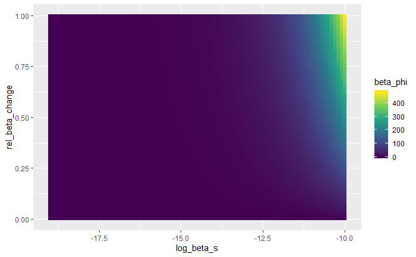

```r
library(tidyverse)
# Define a vector of rel_beta_change
rel_beta_change <- rev(seq(0, 1, by = 0.01))

# Define vector of log_beta_s (based on prelimnary ranges observed from fits)
log_beta_s <- seq(-19, -10, by = 0.1)

# Combine both and back-calculate tranmission
transmission <- expand.grid(rel_beta_change, log_beta_s) %>%
  as_tibble() %>%
  rename("rel_beta_change" = Var1,
         "log_beta_s" = Var2) %>%
  mutate(beta_s = exp(log_beta_s),
         beta_phi = beta_s * rel_beta_change * 10600018)

ggplot(transmission, aes(x = log_beta_s, y = rel_beta_change)) +
  geom_tile(aes(fill = beta_phi)) +
  scale_fill_viridis_c()
```

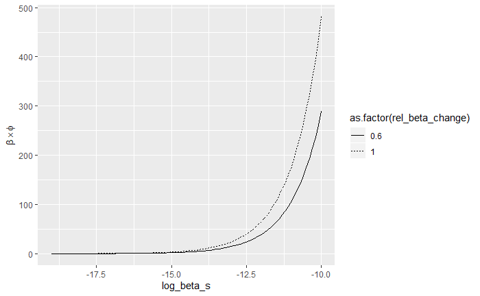

```r
transmission %>%
  filter(rel_beta_change %in% c(1, 0.6)) %>%
  ggplot(aes(x = log_beta_s, y = beta_phi)) +
  geom_line(aes(linetype = as.factor(rel_beta_change))) +
  ylab(bquote(beta %*% phi))
```

In that plot the nonlinearity is obvious. This is why we see much different dynamics depending on baseline `log_beta_s`. Let’s zoom in on what is becoming the expected range, between -18 and -16.

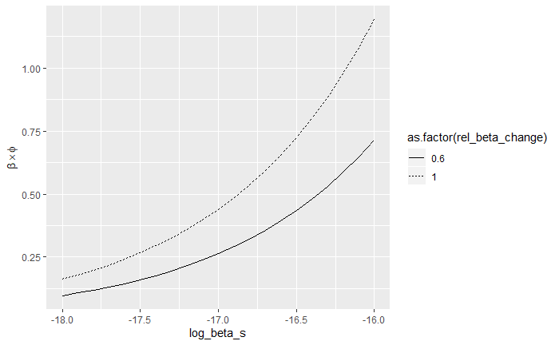

```r
transmission %>%
  filter(rel_beta_change %in% c(1, 0.6)) %>%
  filter(log_beta_s < -15.9 & log_beta_s > -18.1) %>%
  ggplot(aes(x = log_beta_s, y = beta_phi)) +
  geom_line(aes(linetype = as.factor(rel_beta_change))) +
  ylab(bquote(beta %*% phi))
```